# cellGeometry quickstart

Myles Lewis

# 1 Geometric single cell deconvolution

`cellGeometry` has been written for ultrafast deconvolution of bulk RNA-Seq datasets using a single-cell RNA-Seq reference dataset in which cell clusters have been defined.

# 2 Installation

Bioconductor version >=3.20 must be installed first for this package to install correctly. For full package functionality, particularly with sparse matrices stored on disc in the h5ad format, we recommend that the Bioconductor packages zellkonverter, rhdf5 and HDF5Array must also be installed to be able to read h5ad files. If you are using Seurat, then it needs to be installed. We also recommend installing AnnotationHub to enable conversion of ensembl gene ids to symbols.

```r
# Bioconductor must be installed +/- updated first
BiocManager::install(version = "3.xx")  # set to latest version

# minimum necessary Bioconductor packages to install cellGeometry package
BiocManager::install(c("ensembldb", "DelayedArray"))

# packages needed to read h5ad files
BiocManager::install(c("zellkonverter", "rhdf5", "HDF5Array"))

# optional, if you are using Seurat
install.packages("Seurat")

# package needed to convert ensembl gene ids to symbols
BiocManager::install("AnnotationHub")
```

Install from CRAN

```r
install.packages("cellGeometry")
```

Or install from Github

```r
devtools::install_github("myles-lewis/cellGeometry")
```

# 3 Algorithm

The algorithm is performed in two stages:

1. Optimal gene markers for each cell subclass are identified. In this part, each gene is considered as a vector in high dimensions with cell clusters as dimensions.
2. The bulk RNA-Seq is deconvoluted by calculating the vector projection of each bulk RNA-Seq sample against a vector representing each cell cluster in high dimensional gene marker space using the vector dot product. In order to adjust for spillover in the vector projection between cell clusters, a compensation matrix is applied.

After each of these stages, diagnostics can be performed and either the gene signature or deconvolution can be updated.

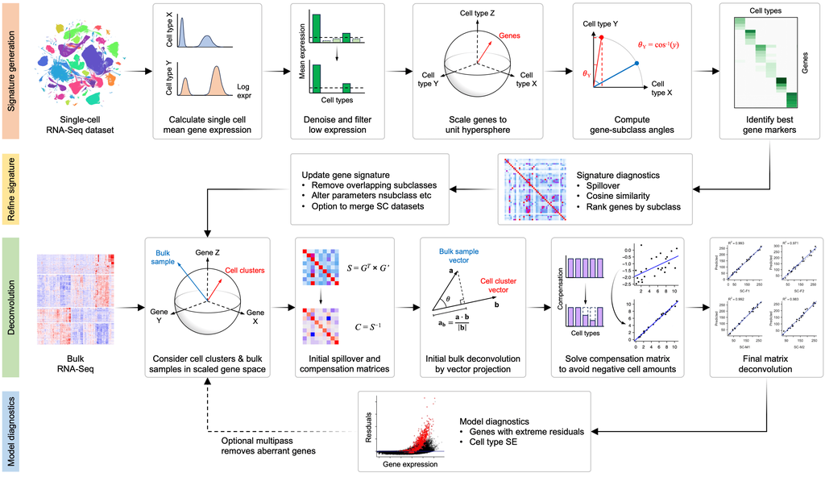

# 4 Example dataset

## 4.1 h5ad file

The following example is based on a the Cell Typist dataset (Global) which contains 329,762 immune cells and is available on the CZ cellxgene repository, described here: https://cellxgene.cziscience.com/collections/62ef75e4-cbea-454e-a0ce-998ec40223d3

The h5ad file (2.9 Gb) for the example can be downloaded from CZ cellxgene repository directly using this link: https://datasets.cellxgene.cziscience.com/2ac906a5-9725-4258-8e36-21a9f6c0302a.h5ad

First we load the file in HDF5 format so that the full data remains on disc and only subsets of the data are loaded/processed when necessary using the HDF5Array and DelayedArray packages.

It is strongly recommended that the file is located on a fast local drive, preferably an SSD, and not a networked drive. For example, an analysis of a midsized dataset only took 10 minutes when the h5 file was stored on a local SSD, compared to 3 hours when the file was stored on a NAS.

```r
library(zellkonverter)
library(SingleCellExperiment)
library(cellGeometry)

typist_h5 <- readH5AD("2ac906a5-9725-4258-8e36-21a9f6c0302a.h5ad",
                      use_hdf5 = TRUE, reader = "R")
```

We extract the main count matrix and cell metadata. cellGeometry needs rownames on the count matrix.

```r
mat <- typist_h5@assays@data$X
rownames(mat) <- rownames(typist_h5)
meta <- typist_h5@colData@listData
```

## 4.2 Seurat file

Some users report difficulties with installing zellkonverter which needs working python libraries. cellGeometry can also be used with Seurat files although these become progressively slower with larger datasets as well as needing substantial amounts of RAM, so for datasets >1M cells we recommend persevering with zellkonverter and the h5ad format since it is much faster. We include example code for loading a Seurat file below as an alternative to h5ad.

At time of writing the rds file (2.9 Gb) in Seurat format can be downloaded from CZ cellxgene repository directly using this link: https://datasets.cellxgene.cziscience.com/2ac906a5-9725-4258-8e36-21a9f6c0302a.rds

CZ cellxgene state that Seurat support will end after Dec 2024.

```r
library(Seurat)
typist <- readRDS("2ac906a5-9725-4258-8e36-21a9f6c0302a.rds")  # 15.5 GB in memory

mat <- typist@assays$RNA$counts
meta <- typist@meta.data
```

# 5 Obtain gene signatures

## 5.1 Extract cell clusters

We first check cell cluster subclasses. Then we extract a vector which contains the subclass cluster for each cell and a 2nd vector for broader cell groups. We restrict the dataset to blood so that we can deconvolute blood bulk RNA-Seq data later (since tissue-based cells should not be found in peripheral blood samples). This reduces the analysis to 27,602 cells out of the total 329,762 cells and reduces the number of subclasses from 43 to 27. This is entirely optional and the algorithm can easily run the full analysis.

```r
table(meta$Majority_voting_CellTypist)

subcl <- meta$Majority_voting_CellTypist
cellgrp <- meta$Majority_voting_CellTypist_high

# reduce dataset to only blood (optional)
subcl[meta$tissue != "blood"] <- NA
cellgrp[meta$tissue != "blood"] <- NA
```

## 5.2 Create gene signature

We then run the 1st stage of cellGeometry which generates mean gene expression for each cell cluster (this is the slowest part). Then the best cell cluster and cell group gene markers are identified.

```r
mk <- cellMarkers(mat, subclass = subcl, cellgroup = cellgrp,
                  dual_mean = TRUE, cores = 2)
```

The `dual_mean` argument only needs to be set for the purpose of the simulation later. Most users do not need to set this. It calculates both the standard mean gene expression, which is mean(log<sub>2</sub>(counts +1)), as well as the arithmetic mean of the (unlogged) counts.

The derivation of mean gene expression for each cluster and cell group is the slowest part. If you are on linux or mac, this can be sped up using parallelisation by setting `cores = 2` or more. Note that this can increase memory requirements dramatically unless HFD5 is used. For this particular dataset which is moderate in size, we find significant speed up with 4-8 cores (64 Gb machine). For very large datasets (>1M cells) if the sc data is kept on disc via HFD5 then many cores can be used. But if the data or subsets of it have to be loaded into memory then we typically apportion around 16 Gb per core (e.g. 3 cores on a 64 Gb machine). So the limit on cores depends on the size of the single-cell data, available RAM and whether HFD5 is used.

Windows users can invoke parallelisation using the future backend and setting up a multisession plan.

```r
# example code using future for parallelisation on windows
library(future)
plan(multisession, workers = 4)

mk <- cellMarkers(mat, subclass = subcl, cellgroup = cellgrp,
                  use_future = TRUE)
```

We have not specified a bulk RNA-Seq dataset at this stage as this example is based on simulation alone. However, if you have a bulk RNA-Seq dataset it is helpful to specify it during the first call to `cellMarkers()`. It is only used for its rownames to identify genes that overlap between the 2 datasets. The marker signature can be updated later for different bulk datasets using `updateMarkers()` (see below).

We convert the ensembl ids in the cellMarkers object using the built-in function `gene2symbol()`. This needs an ensembl database to be loaded.

```r
library(AnnotationHub)
ah <- AnnotationHub()
ensDb_v110 <- ah[["AH113665"]]
mk <- gene2symbol(mk, ensDb_v110)
```

## 5.3 Visualise gene signature

The signature gene matrix can be displayed as follows.

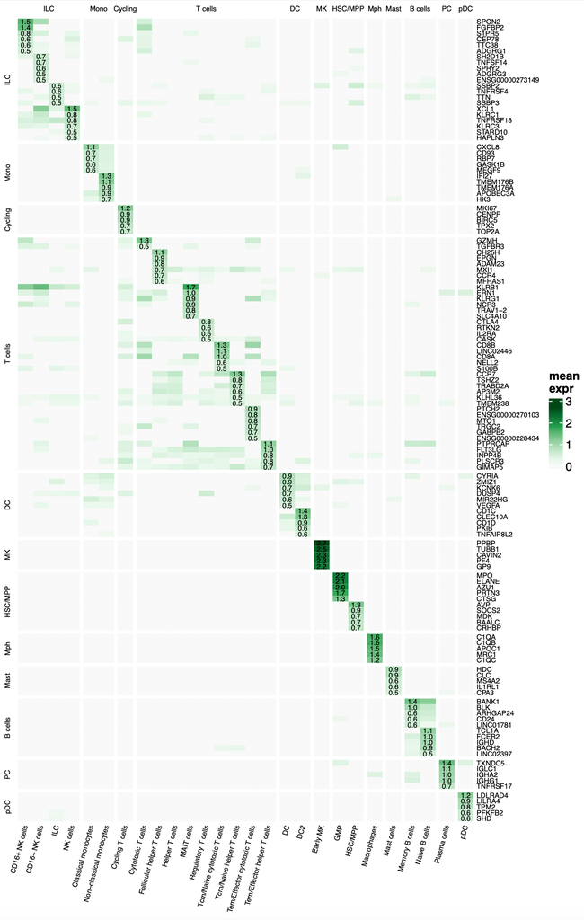

```r
signature_heatmap(mk)  # visualise whole signature
signature_heatmap(mk, top = 5)  # show top 5 genes for each subclass
```

The default signature heatmap shows the gene signature after the noise filter has been applied. To see the raw gene expression heatmap call `signature_heatmap()` with `use_filter = FALSE`.

The spillover heatmap between cell clusters can also be visualised.

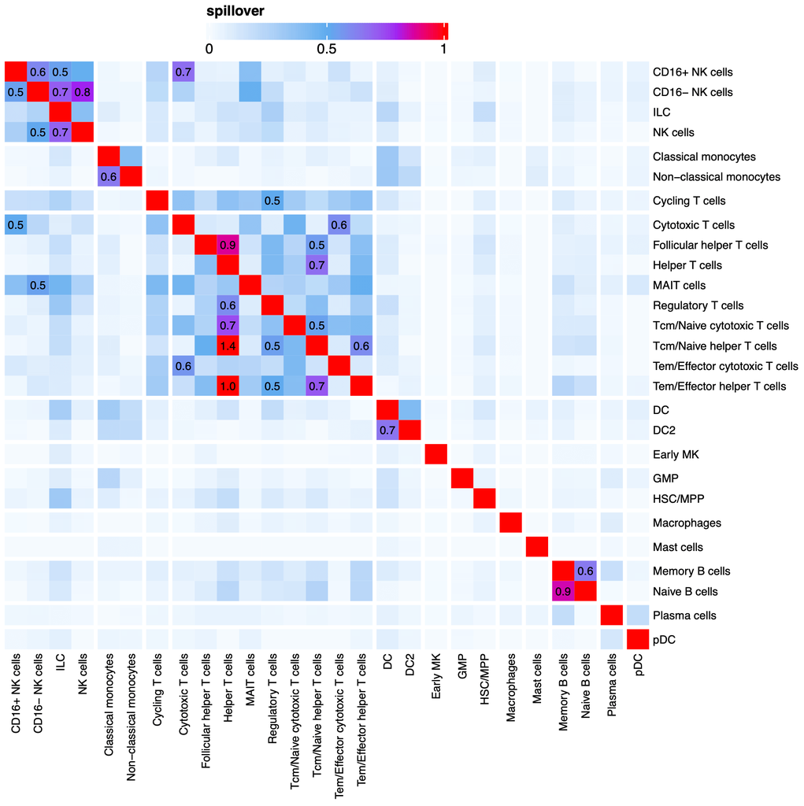

```r
spillover_heatmap(mk)
```

This heatmap as well as the signature heatmap reveals that some cell subclasses ‘spillover’ too strongly into other cell subclasses. In other words some cell types are too similar - perhaps one is really a closely related subset of the other. Here we see that Helper T cells are the most affected and their signature is similar to Tcm/Naive helper T cells.

## 5.4 Signature diagnostics

When cell clusters exhibit spillover, it is generally because of cell types being too similar. Cosine similarity is an ideal method for detecting this as it explicitly measures the angle between the vectors for each cell subclass as defined by in gene space. `cos_similarity()` generates a cosine similarity matrix for the cell subclasses, and this can be visualised using a heatmap.

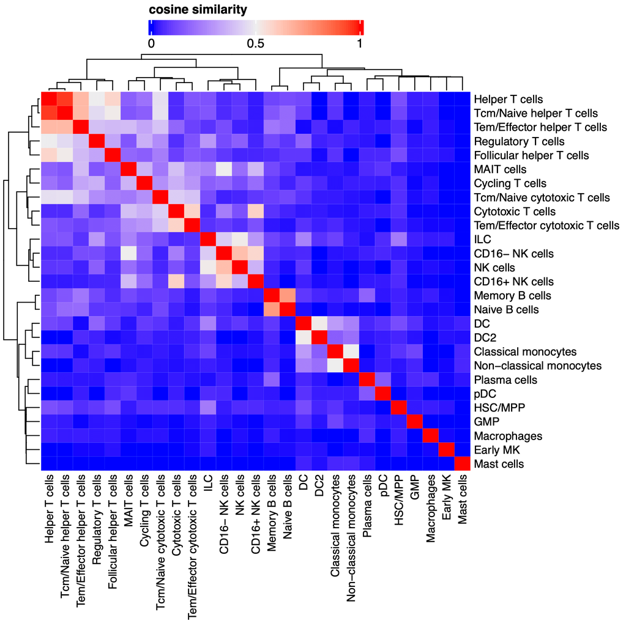

```r
cs <- cos_similarity(mk)
ComplexHeatmap::Heatmap(cs)
```

The cosine similarity matrix is easily be converted to the angle between the vectors for each cell subclass using `acos(cs)`. The function `rank_angle()` can be used to list those pairs of subclasses whose vectors are close together in terms of the angle between them.

```r
rank_angle(cs)
```

This plus the cosine similarity heatmap confirms that the vector for Helper T cells is rather similar to the vector for Tcm/Naive helper T cells, which is not surprising as these cell types overlap.

The `diagnose()` function provides more thorough diagnostics on the gene signature. It can be used to identify which cell clusters are problematic. Helper T cells in particular do not have any top ranked markers of their own since they are largely identical to Tcm/Naive helper T cells in terms of their gene expression.

```r
diagnose(mk)
```

Below we update the cellMarkers object to remove 2 cell clusters which overlap with other cell clusters and are therefore likely to be difficult to deconvolute well if applied to real world bulk RNA-Seq. (For the simulation it actually does not matter whether these are removed or not since the algorithm is able to differentiate them sufficiently.)

```r
mk <- updateMarkers(mk,
                    remove_subclass = c("Helper T cells", "Cytotoxic T cells"))
```

## 5.5 Refine gene signature

The following arguments are available in both `cellMarkers()` or `updateMarkers()`. They can change and improve which genes are selected for the gene signature as well as changing the amount of noise reduction in the gene signature if the filter is applied during deconvolution by `deconvolute()`.

| `nsubclass` | Number of genes to select for each single cell subclass. Either a single number or a vector with the number of genes for each subclass. |
| --- | --- |
| `ngroup` | Number of genes to select for each cell group. Either a single number or a vector with the number of genes for each group. |
| `expfilter` | Genes whose maximum mean expression on log2 scale per cell type are below this value are removed and not considered for the signature. |
| `noisefilter` | Sets an upper bound for `noisefraction` cut-off below which gene expression is set to 0. Essentially gene expression above this level must be retained in the signature. Setting this higher can allow m… |
| `noisefraction` | Numeric value from 0-1 (default 0.25). Higher values mean more noise suppression. Maximum mean log2 gene expression across cell types is calculated and values in celltypes below this fraction are set … |

`nsubclass` and `ngroup` simply define how many genes are picked for each subclass or group. If some subclasses do not have enough specific genes, lowering `expfilter` is probably the first parameter to try. However as `expfilter` approaches zero, lots of genes with very low expression but which appear to be highly specific to a subclass (i.e. only expressed in that subclass with zero expression in all other cell clusters) will be selected. Although these might perform well in simulations, our experience is that they are poor markers in real bulk RNA-Seq.

In addition users have full control over editing the gene list for the subclass signature using the `add_gene` and `remove_gene` arguments in `updateMarkers()`. Similarly `add_groupgene` and `remove_groupgene` can be used to edit the gene list for the broader cell group signatures.

# 6 Deconvolution

We can generate pseudo-bulk to test the deconvolution using the following commands. First, `generate_samples()` makes 25 samples with random cell counts, `sim_counts`.

```r
# simulated bulk
set.seed(3)
sim_counts <- generate_samples(mk, 25)
sim_percent <- sim_counts / rowSums(sim_counts) * 100
```

## 6.1 Sampled pseudo-bulk

Then the original scRNA-Seq count dataset is sampled. The actual cell counts in `sim_counts` can be oversampled by setting `times`. The desired cell counts are simply multiplied by `times` prior to sampling. Cells are sampled with replacement. By default, sampling is performed using the Dirichlet distribution as this gives true random sampling in comparison to uniform sampling. When cells are oversampled uniformly, in the limit the summed gene expression tends to the arithmetic mean of the subclass x sample frequency (which is a much easier deconvolution problem compared to Dirichlet sampling). This can be demonstrated by using uniform sampling and steadily increasing `times` from 1 to 30-100 or more. This improves the deconvolution as the sum of the gene counts per sampled cell approaches the arithmetic mean of gene counts for each cell cluster.

```r
# sample from original sc count matrix
# 1.43 mins (Intel); 45 secs (ARM)
set.seed(99)
times <- 1  # can be increased
sim_sampled <- simulate_bulk(mat, sim_counts, subcl, times = times)

# fix rownames
rownames(sim_sampled) <- gene2symbol(rownames(sim_sampled), ensDb_v110)
```

Deconvolution itself is performed using the function `deconvolute()`. The `plot_set()` function can be used to plot the results. This generates multiple plots over 1 or more pages, with a scatter plot for each cell subclass. An alternative way to visualise the results is to use `plot_pred()` which generates a single scatter plot, with each cell subclass given a different colour. The `metric_set()` function generates a table of results.

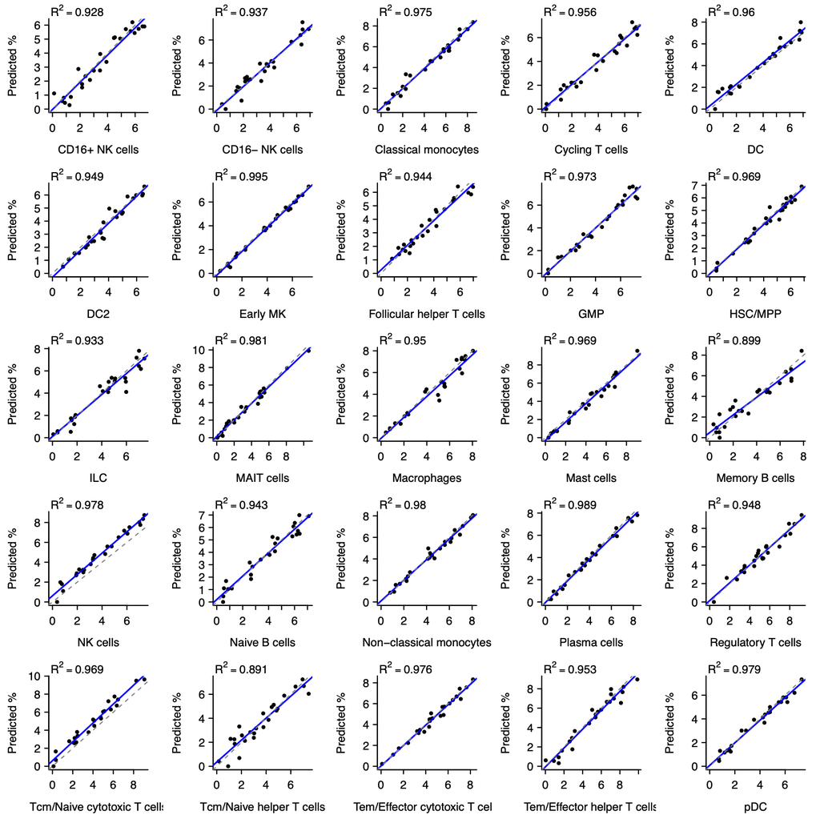

```r
# near optimal deconvolution of counts sampled from the original scRNA-Seq
fit <- deconvolute(mk, sim_sampled,
                   use_filter = FALSE, arith_mean = TRUE)

# plot results - multiple scatter plots
plot_set(sim_counts, fit$subclass$output / times)  # adjust for oversampling using `times`
plot_set(sim_percent, fit$subclass$percent)

# alternative plot - single scatter plot
plot_pred(sim_counts, fit$subclass$output / times)

# stats table
metric_set(sim_percent, fit$subclass$percent)
```

Results are returned in `fit$subclass$output` for standard output (theoretically in numbers of cells), `fit$subclass$percent` for output converted to percentage of total cells for each sample. The group analysis is returned in a similar vein in `fit$group$output` and `fit$group$percent`.

## 6.2 Real bulk RNA-Seq settings

We recommend that bulk RNA-Seq sample data is provided as raw counts. Log<sub>2</sub> transformed data can be inputted, but it is important that the transformed data is *not* offset, i.e. the algorithm expects that zero in the bulk really means zero expression. Some transformation methods, e.g. variance stabilising transform (VST), mean that there is an offset so that zero counts equates to a positive number. This typed of transformed data cannot be used.

With a real bulk RNA-Seq dataset the first step is to ensure that only genes which are present in the bulk data are used for the gene signatures. This is achieved using the function `updateMarkers()`.

```r
mk <- updateMarkers(mk, bulkdata = my_bulk_matrix)
```

Alternatively bulk data can be supplied with the first call to `cellMarkers()`. `updateMarkers()` can also be used to rapidly update the marker object `mk` with new settings, e.g. to alter the number of genes used per subclass or manually edit (add/remove) the marker genes. Note that if some signature genes are missing from the bulk data, `deconvolute()` will stop with an error message that some signature genes are missing.

Note that the settings shown above are mathematically ideal for simulated bulk data. In reality, we expect the scRNA-Seq signature to differ from real-world bulk RNA-Seq due to differences in chemistry and the amplification step required by single-cell sequencing. So we recommend the default settings for real-world bulk data when calling `deconvolute()`. The main settings to choose here are:

| Parameter | Optimal simulation | Real-world recommended | Purpose |
| --- | --- | --- | --- |
| `count_space` | TRUE | TRUE | Toggles whether the deconvolution is performed in count space (exponential space) or in log<sub>2</sub> space. |
| `weight_method` | “equal” | “equal” | Scaling is applied so that each gene in the gene signature has equal weight. |
| `convert_bulk` | FALSE | FALSE | Converts the bulk RNA-Seq onto scRNA-Seq data scale based on a reference dataset in which both bulk and scRNA-Seq were performed simultaneously. |
| `use_filter` | **FALSE** | TRUE | Reduces the overall amount of spillover & compensation by denoising the gene signatures. |
| `arith_mean` | **TRUE** | FALSE | Whether to use arithmetic mean of counts or the standard log<sub>2</sub> mean. |

We recommend `use_filter` is always on for real-world bulk analysis as it reduces the compensation burden particularly for genes where non-specific low level expression is present in some cell clusters which can occur even for good markers. We suggest `deconvolute()` is used in one of 2 modes: either `convert_bulk = TRUE` or `count_space = TRUE`, but **not both**.

There is also a powerful function `tune_deconv()` which allows users to tune any of the parameters available in `updateMarkers()` based on a bulk reference dataset. The simulated pseudo-bulk data can be used for this purpose, but real bulk RNA-Seq would be better (more realistic and better for tuning).

Also, 2 scRNA-Seq datasets can be merged using the function `mergeMarkers()`. This merges the `cellMarkers` objects derived from each single cell dataset. One dataset is defined as reference, and the 2nd dataset is merged into it after adjustment for its overall distribution based on quantile mapping.

# 7 Tuning deconvolution

The function `tune_deconv()` can be used with the sampled pseudo-bulk matrix `sim_sampled` which we generated earlier to see the effect of tuning parameters for deconvolution. Note there are important mathematical caveats to understand when using tuning. Below we tune over a range of `nsubclass` values from 5 up to 1000, vary the low expression filter `expfilter` from 0.05 up to 1.5, and also tune `weight_method` to either “none” or “equal”. But any argument which can be passed to `updateMarkers()` can be tuned. Arguments which are not in the tuning list specified through the argument `grid` such as `arith_mean` and `use_filter` in the example below are applied constantly via the `...` system.

```r
res <- tune_deconv(mk, sim_sampled, sim_counts * times,
                   grid = list(nsubclass = c(5, 10, 15, 25, 50, 100, 200, 500, 1000),
                               expfilter = c(0.05, 0.1, 0.25, 0.5, 0.75, 1, 1.5),
                               weight_method = c("none", "equal")),
                   arith_mean = TRUE,
                   use_filter = FALSE)

## Tuning parameters: nsubclass, expfilter, weight_method
##   |==========================================================| 100%, Elapsed 00:07
## Best tune:
##   nsubclass  expfilter  weight_method  mean.RMSE
##        1000       0.25          equal      35.21
```

When tuning it is important not to forget the effect of `times` in `simulate_bulk()`. That is why the supplied true cell counts matrix `sim_counts` is multiplied by the oversampling factor `times` in the above example.

The results of tuning can be plotted using the function `plot_tune()`.

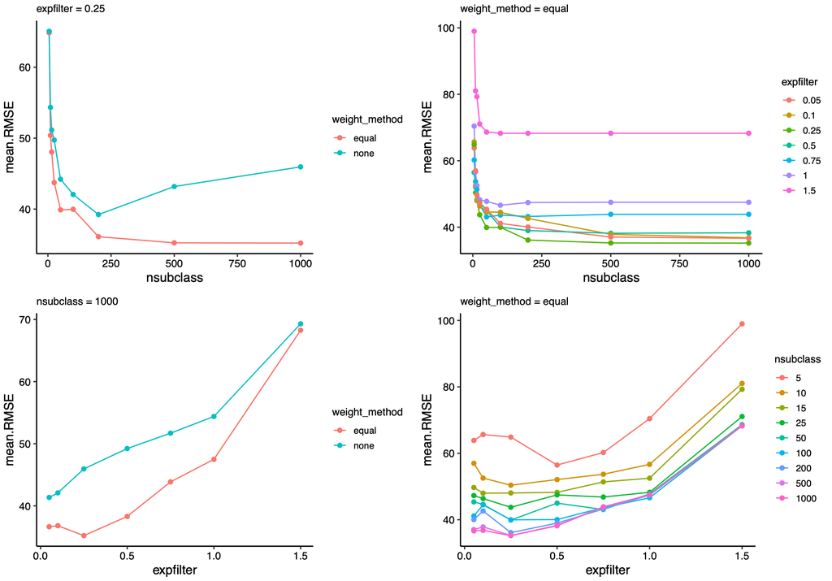

```r
plot_tune(res, xvar = "nsubclass", group = "weight_method")
plot_tune(res, xvar = "nsubclass", group = "expfilter")
plot_tune(res, xvar = "expfilter", group = "weight_method")
plot_tune(res, xvar = "expfilter", group = "nsubclass")
```

These plots show that `weight_method = "equal"` is better than `"none"` and that `expfilter` for this single cell dataset seems to be optimal at around 0.25. In this simulation the higher `nsubclass` is the better, with deconvolution best with 500-1000 genes per subclass. In reality we find that this is unlikely to be true for real-world bulk RNA-Seq as noise caused by differences in sequencing chemistry mean that larger numbers of genes in the signature add increasing noise, so there is likely to be a sweetspot. The default `nsubclass` is 25 which has been chosen as a plausible compromise which should work in most situations.

## 7.1 Simulating noise

The package provides several noise adding functions which can be applied to the sampled simulation dataset.

```r
# simple gaussian noise applied to counts
sim_noise <- add_noise(sim_sampled)

# noise applied to log2 counts
sim_noise <- log_noise(sim_sampled)

# noise applied to sqrt transformed counts
sim_noise <- sqrt_noise(sim_sampled)

# whole genes are scaled up/down by a random amount
# this simulates differences in chemistry
sim_noise <- shift_noise(sim_sampled)
```

Tuning can then be tested on the simulation data with added noise to see how tolerant the deconvolution parameters are to different types of noise.

```r
res2 <- tune_deconv(mk, sim_noise, sim_counts,
                   grid = list(nsubclass = c(5, 10, 15, 25, 50, 100, 200, 500, 1000),
                               expfilter = c(0.05, 0.1, 0.25, 0.5, 0.75, 1, 1.5),
                               weight_method = c("none", "equal")),
                   arith_mean = TRUE,
                   use_filter = FALSE)
```

We find that the addition of simple noise to the simulation dataset tends to prefer higher `nsubclass` as this averages out the noise across more markers. `shift_noise` which simulates differences in chemistry tends to show that the low expression filter `expfilter` becomes increasingly important and that in some datasets there is a maximum limit to `nsubclass`.

# 8 Deconvolution diagnostics

## 8.1 Standard error

Several methods are available to calculate standard errors on a fitted deconvolution model which can be accessed using the `se()` function. These give an estimate of the uncertainty/reliability of deconvolution. Note that the default method which we show to the most accurate gives a vector of SE estimates with an SE value for each cell subclass but across all bulk samples. The other methods which are based on ordinary least squares or extensions such as heteroscedasticity-consistent standard errors using methods HC0, HC2 and HC3, produce a matrix of SE estimates per subclass and per sample, but these are considerably noisier and in our view less reliable.

```r
# default method using var.e (see paper for details)
se1 <- se(fit)
head(se1)

# ordinary least squares
se2 <- se(fit, type = "OLS")
```

Related to this, the condition number of the spillover matrix from a deconvolution model can be accessed using `kappa()`. In our experience, kappa tends to be very high with sc-to-bulk deconvolution, because the input data, which is count data, is on an exponential scale and extremely skewed. Also, most users actively want to try to deconvolute cell types that are related e.g. subsets of neurons, subsets of B/T-cells etc. This means that the single-cell reference gene signature has a strong tendency to collinearity.

## 8.2 Confidence intervals

Based on the standard error calculation, confidence intervals (default level 95%) can be calculated for all samples using `confint()`.

```r
# default method using var.e (see paper for details)
ci1 <- confint(fit)
str(ci1)

# ordinary least squares
ci2 <- confint(fit, type = "OLS")
```

## 8.3 Residual gene expression

Residual gene expression values can be accessed using `residuals()`. Residuals are calculated based on the gene signature matrix and stored within the model object. A full table of residuals for all genes can be produced by providing the original bulk (or pseudobulk) matrix.

```r
r <- residuals(fit)

# full table including all genes
r1 <- residuals(fit, test = sim_sampled)
```

Residuals can be visualised with the function `plot_residuals()`. This shows residuals across all bulk samples on the *y* axis with bulk gene expression along the *x* axis. Residuals can either be plotted with or without the effect of equal gene weighting, or as Studentized residuals. A ggplot2 version is available via `ggplot_residuals()`.

```r
# fitted values for bulk on x axis
plot_residuals(fit)

# actual bulk gene expression - good for spotting outliers with massive expression
plot_residuals(fit, sim_sampled)
plot_residuals(fit, sim_sampled, type = "raw")
plot_residuals(fit, sim_sampled, type = "student")
```

Functions that can help users decide if genes are outliers include standardized or Studentized residuals which can be computed using `rstandard()` and `rstudent()` respectively. Cook’s distance can also be calculated using `cooks.distance()`.

```r
rs1 <- rstandard(fit)
rs2 <- rstudent(fit)
cooksd <- cooks.distance(fit)
```

## 8.4 Multipass outlying gene removal

Genes which are outliers based on extreme residual gene expression are flagged automatically by the `deconvolute()` function and users alerted with a message `"Detected genes with extreme residuals ..."`. These can be removed by successive passes of deconvolution by setting the argument `npass` to >= 2. This is generally unnecessary in simulations unless large amounts of noise have been added to the pseudo-bulk. But it may be necessary with real-world data, especially if cell types which are present in the bulk data are missing from the reference scRNA-Seq. The multi-pass system stops automatically if no more outliers can be detected. However, if thresholds for determining outliers are set too low, the process can go on forever.

```r
sim_noise <- shift_noise(sim_sampled)
fit2 <-  deconvolute(mk, sim_noise, npass = 4,
                     use_filter = FALSE, arith_mean = TRUE)
```

## 8.5 Variable compensation

cellGeometry autotunes compensation for each cell subclass independently as part of the mechanism to prevent negative cell counts in the deconvolution results. The package includes functions to visualise the effects of varying compensation. To enable these, the argument `comp_check` must be set to `TRUE` when calling `deconvolute()`. With simple simulations, the compensation values are all very close to 1. However, this system is more deeply invoked and necessary with real-world bulk samples.

```r
fit2 <-  deconvolute(mk, sim_noise,
                     use_filter = FALSE, arith_mean = TRUE, comp_check = TRUE)

# show minimum deconvolution values across all samples to see where comp cut-offs occur
plot_comp(fit2)

# show coefficient paths for a single subclass (across all samples)
plot_path(fit2)

# show coef paths as cell percentages
plot_path(fit2, type = "percent")

# show coef paths for the first bulk sample (across all subclasses)
plot_path(fit2, sample = 1)
plot_path(fit2, sample = 1, type = "percent")
```

# 9 Citation

If you use this package, please cite as:

Lau, R., Çubuk, C., Spiliopoulou, A., Martínez-Paz, P., Surace, A.E.A., Fossati-Jimack, L., Raychaudhuri, S., Pitzalis, C., Lewis, M.J. cellGeometry: ultra-fast single-cell deconvolution of bulk RNA-Seq using a geometric solution. Nat Commun 17, 8995 (2026). [doi:10.1038/s41467-026-75762-7](https://doi.org/10.1038/s41467-026-75762-7)